# NHIS 2022 Child Health Needs Analysis

M. Cole Callen

# Exploring children’s speech-language and mental health differences across the United States

The following report has two primary objectives:

- First, I present nationwide data on children with **speech-language difficulties** across the U.S. in terms of prevalence. I am specifically interested in the percentage of children who demonstrate difficulties with either speech or language, and how this percentage may differ across different social and economic factors.
- Second, I share a brief report of an analysis of children’s mental health needs nationwide.

## **Key Insights**

### Language and Speech insights

- Language difficulties are reported for approximately 1 in 25 children (in 2022)
- Children whose parents reported a *language difficulty* tend to
  - come from families with lower household income,
  - be covered under publicly-funded health insurance (e.g., Medicaid, CHIP),
  - come from racial and ethnic minority groups, especially American Indian/Alaskan Native and Black/African American.
- Similar trends are shown for children with reported *speech difficulties*.
- Parents tend to report that their children have difficulties with both language and speech, rather than only speech *or* language alone.

### Mental Health Need insights

- The prevalence of children’s mental health need is lower than 1% across the United States.
- Household income seems to be associated with mental health need, but further indicators of mental health need should be examined.

*The analysis was conducted using methods and tools from the `survey`, `dplyr`, `stats`, and `ggplot2` packages in R/RStudio. The data come from the CDC’s National Health Interview Survey conducted in 2022.*

```r
# Full design; subset per analysis below
nhis_design <- svydesign(id = ~PPSU, strata = ~PSTRAT,
                         weights = ~WTFA_C, nest = TRUE,
                         data = NHIS22_recoded)

lang_design   <- subset(nhis_design, LangDiff_YN %in% c(0, 1))
speech_design <- subset(nhis_design, SpeechDiff_YN %in% c(0, 1))
mh_design     <- subset(nhis_design, MH_YN %in% c(0, 1))
```

## Section 1. Children with Language and Speech Difficulties

In speech-language pathology, clinical criteria for language disorders and speech disorders are considered independent. This means that a child can be diagnosed with a speech disorder without a language disorder, and vice versa. Below, we take a brief look at whether reported speech difficulties are related to reported language difficulties.

### 1a. Language

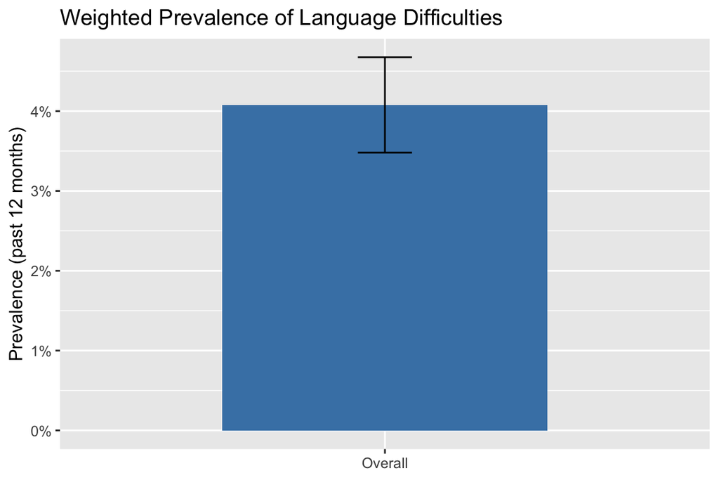

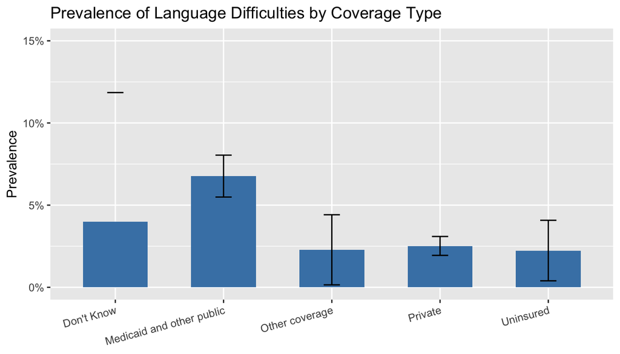

The above graph visualizes the prevalence of language difficulties in children across the United states grouped by their type of health insurance coverage. Those children covered by Medicaid or other public health insurance policies show the highest prevalence of language difficulties. Uninsured children, those with private insurance coverage, and those with “other” types of coverage all show relatively low prevalence. Type of coverage may be closely linked to other social and economic factors, which are explored below.

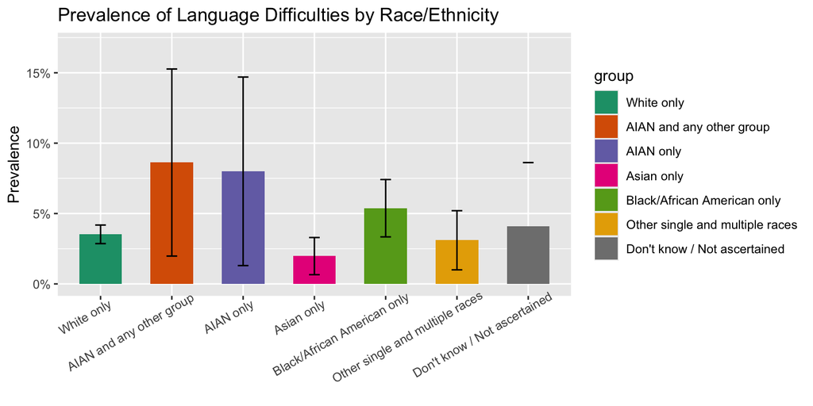

The language(s) used by people of racial and/or ethnic minority populations tend to be stigmatized, which can lead to misdiagnosis in speech-language pathology settings. Examples of the variety of language use can include non-mainstream dialects (e.g., Chicano English, African-American Vernacular English, Appalachian English) or multilingualism (e.g., migrant populations with varying levels of English language proficiency).

[figure not shown]

Finally, we explore the differences in income as the poverty ratio. A higher ratio means that the family’s income is greater than the poverty line. For example, a poverty ratio of 6 means that the family income is 6 times larger than the poverty line for that family size.

Here, we see that children presenting with language difficulties tend to come from lower income families. This pattern likely reflects the fact that lower income families typically have fewer educational opportunities. For that reason, parents may be reporting language difficulties in reading or writing, and not necessarily difficulties with everyday language or communication.

This income-based difference also relates to the differences found for health insurance coverage: children covered by Medicaid showed a higher prevalence of language difficulties. Because income is a primary criterion in eligibility for Medicaid coverage, the trend of overall lower median family income for children with language difficulties may factor into how coverage type is related to language difficulties and/or diagnoses of language disorders.

Using survey regression modelling in R, family income shows a more prevalent relationship with language difficulties than health insurance coverage. In other words, the likelihood of having a language difficulty is higher for children from lower income families (near or below the median income-to-poverty ratio). A similar statistical association is found between family income and speech difficulties.

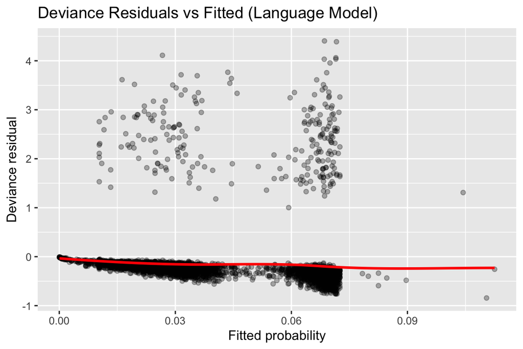

### 1b. Speech

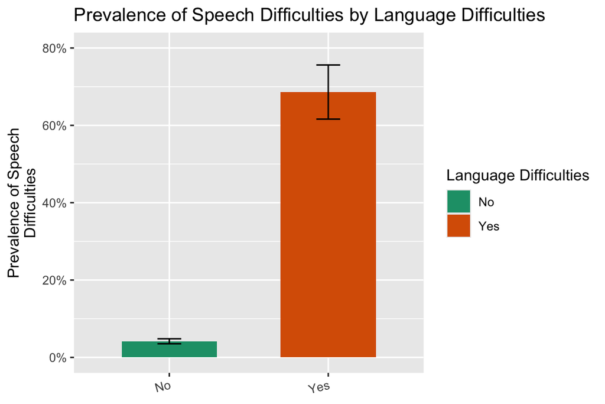

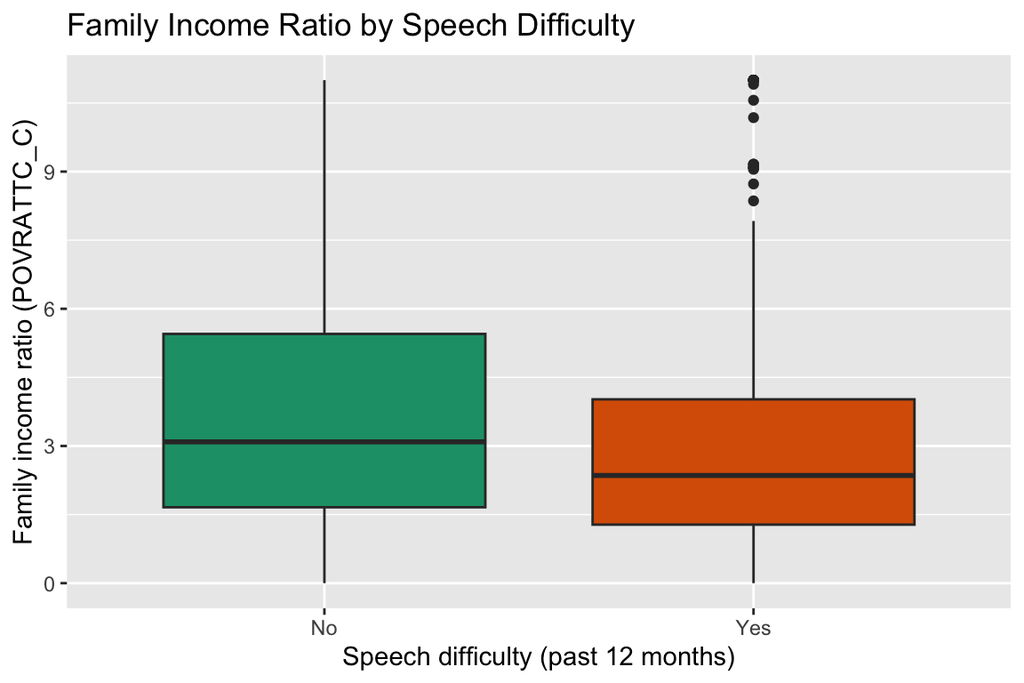

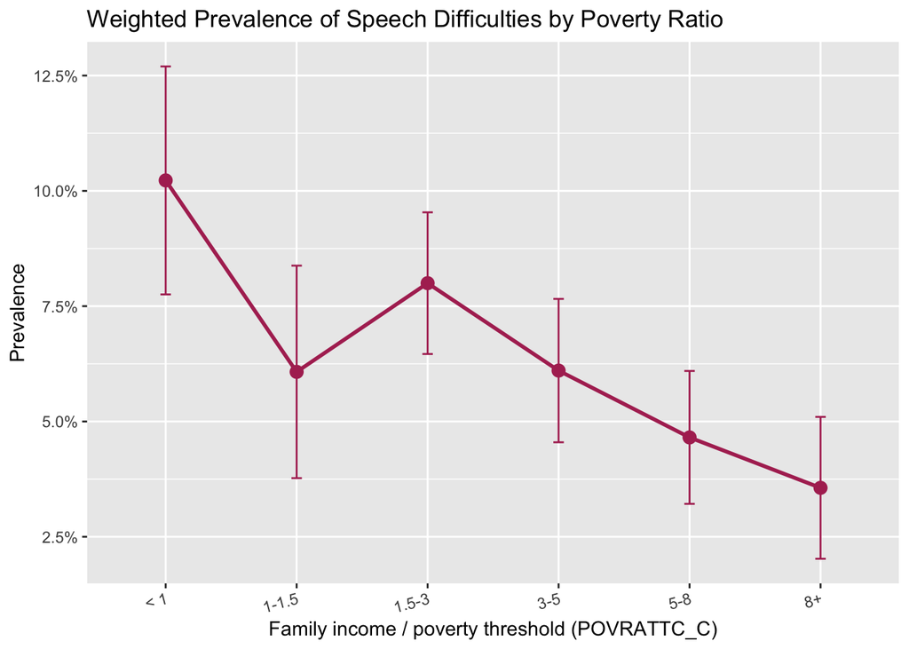

The differences above show that the pattern of family income ratio is similar for children with speech difficulties as for children with language difficulties. Children from lower-income families tend to have a higher prevalence of speech difficulties compared to those from higher-income families.

Below, we see that prevalence of speech difficulties is also associated with health insurance coverage type, similar to the trend seen for language difficulties.

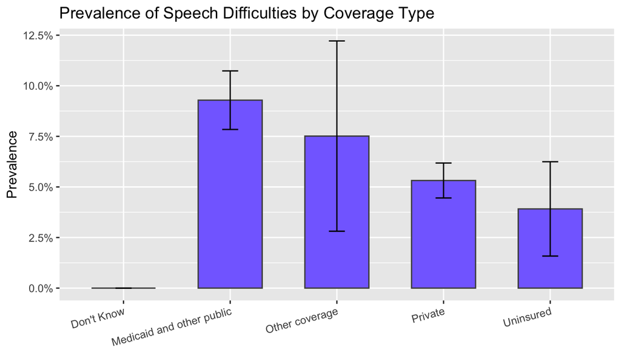

Survey-weighted logistic regression: speech difficulty ~ coverage x income ratio

| term | estimate | std.error | statistic | p.value | conf.low | conf.high |
| --- | --- | --- | --- | --- | --- | --- |
| (Intercept) | 0.0899350 | 0.1721936 | -13.9881395 | 0.0000000 | 0.0641261 | 0.1261313 |
| Coverage_glmDon’t Know | 0.0000048 | 0.4749352 | -25.7915641 | 0.0000000 | 0.0000019 | 0.0000122 |
| Coverage_glmMedicaid and other public | 1.1375790 | 0.2232416 | 0.5774117 | 0.5638972 | 0.7337357 | 1.7636951 |
| Coverage_glmOther coverage | 0.9945425 | 0.8758481 | -0.0062481 | 0.9950170 | 0.1780159 | 5.5563274 |
| Coverage_glmUninsured | 0.3651766 | 0.5964102 | -1.6890629 | 0.0917731 | 0.1131671 | 1.1783811 |
| POVRATTC_C | 0.9023126 | 0.0325380 | -3.1592086 | 0.0016687 | 0.8464469 | 0.9618656 |
| Coverage_glmDon’t Know:POVRATTC_C | 1.1378525 | 0.0988697 | 1.3061910 | 0.1920326 | 0.9370066 | 1.3817495 |
| Coverage_glmMedicaid and other public:POVRATTC_C | 1.1088442 | 0.0719876 | 1.4352222 | 0.1517912 | 0.9626306 | 1.2772661 |
| Coverage_glmOther coverage:POVRATTC_C | 1.0777966 | 0.2348717 | 0.3189774 | 0.7498645 | 0.6794751 | 1.7096220 |
| Coverage_glmUninsured:POVRATTC_C | 1.2035585 | 0.1753022 | 1.0569328 | 0.2910054 | 0.8529454 | 1.6982952 |

## Section 2: Children’s Mental Health Needs

Finally, we look at how children’s mental health needs vary by socioeconomic and geographic factors.

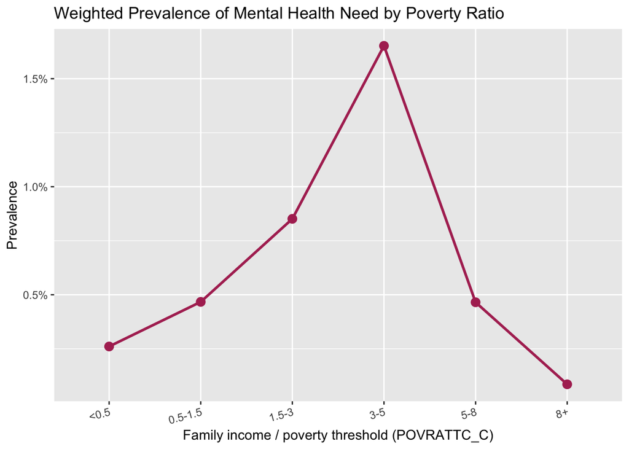

Looking above at the relationship between Family income and prevalence of children’s mental health needs, we see that mental health needs are most prevalent in the poverty ratio range of 3-5. It is not immediately clear why this trend would peak in this specific income range. Other factors may play a role in mental health needs.

Next, we look at geographic factors that might be related to children’s mental health needs.

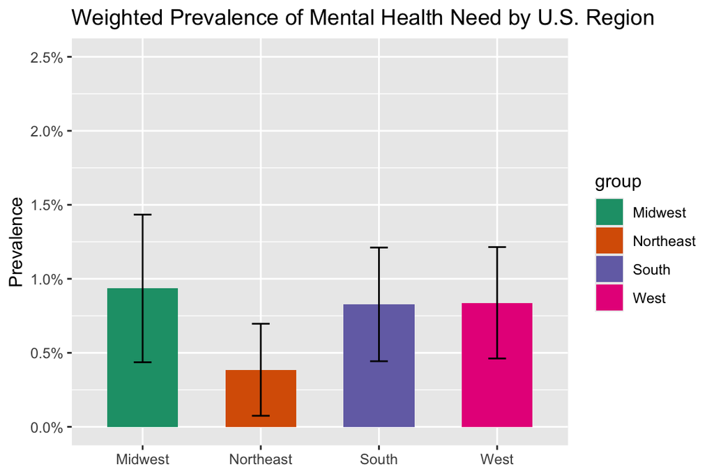

The graph shows the prevalence of children’s mental health needs across four predetermined regions of the U.S. The South and West regions show very similar prevalence patterns, and the Midwest shows the highest prevalence (nearly 1%), although not much higher than the other two. Northeast shows the lowest prevalence of mental health needs in children (around 0.4%).

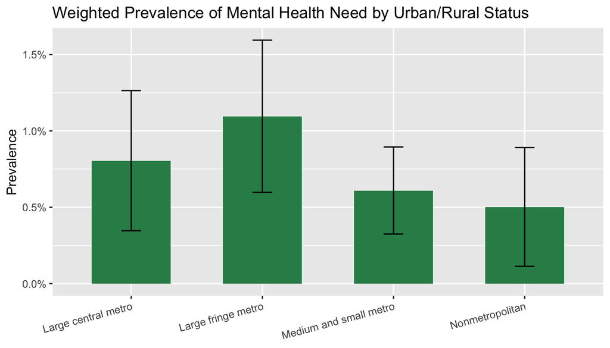

Explanations of each geographical category:

- *large central metropolitan areas* include counties containing large and more densely-populated cities like San Francisco, CA; Minneapolis-Saint Paul, MN; Miami, FL; and Boston, MA
- *large fringe metropolitan areas* mostly include counties surrounding the large fringe metros as well as highly, but more sparsely populated counties (e.g., areas colloquially called “suburban”)
- *medium and small metro areas* tend to have both lower density and lower overall population
- *nonmetropolitan areas* are typically rural and/or very sparsely populated

*For more information, see the CDC’s resource on how these categories were determined: https://www.cdc.gov/nchs/data-analysis-tools/urban-rural.html.*

Survey-weighted logistic regression: mental health need ~ urban/rural + coverage + income ratio

| term | estimate | std.error | statistic | p.value | conf.low | conf.high |
| --- | --- | --- | --- | --- | --- | --- |
| (Intercept) | 0.0186241 | 0.4173553 | -9.5441466 | 0.0000000 | 0.0082043 | 0.0422772 |
| URBRRL_glmLarge fringe metro | 1.3420541 | 0.3873301 | 0.7595623 | 0.4478393 | 0.6271222 | 2.8720224 |
| URBRRL_glmMedium and small metro | 0.7285866 | 0.3804590 | -0.8322809 | 0.4056090 | 0.3450840 | 1.5382875 |
| URBRRL_glmNonmetropolitan | 0.5620470 | 0.5019981 | -1.1477531 | 0.2515659 | 0.2096696 | 1.5066408 |
| Coverage_glmDon’t Know | 0.0000003 | 0.3434454 | -43.9127965 | 0.0000000 | 0.0000001 | 0.0000006 |
| Coverage_glmMedicaid and other public | 0.3608602 | 0.3910062 | -2.6067738 | 0.0093861 | 0.1674114 | 0.7778444 |
| Coverage_glmOther coverage | 0.0000003 | 0.2345607 | -64.5061955 | 0.0000000 | 0.0000002 | 0.0000004 |
| Coverage_glmUninsured | 1.9337530 | 0.4577520 | 1.4406549 | 0.1502471 | 0.7868803 | 4.7521846 |
| POVRATTC_C | 0.8618005 | 0.0461217 | -3.2247585 | 0.0013351 | 0.7871580 | 0.9435211 |

Survey-weighted logistic regression with urban/rural x coverage interaction

| term | estimate | std.error | statistic | p.value | conf.low | conf.high |
| --- | --- | --- | --- | --- | --- | --- |
| (Intercept) | 0.0153690 | 0.5683070 | -7.3470948 | 0.0000000 | 0.0050329 | 0.0469322 |
| URBRRL_glmLarge fringe metro | 1.3147624 | 0.5792552 | 0.4724272 | 0.6368120 | 0.4213867 | 4.1021707 |
| URBRRL_glmMedium and small metro | 1.0294354 | 0.5650418 | 0.0513422 | 0.9590717 | 0.3392800 | 3.1234892 |
| URBRRL_glmNonmetropolitan | 1.2180827 | 0.6268841 | 0.3146962 | 0.7531134 | 0.3555313 | 4.1732629 |
| Coverage_glmDon’t Know | 0.0000001 | 0.7417939 | -21.5004945 | 0.0000000 | 0.0000000 | 0.0000005 |
| Coverage_glmMedicaid and other public | 0.6857562 | 0.6567910 | -0.5743578 | 0.5659640 | 0.1887370 | 2.4916241 |
| Coverage_glmOther coverage | 0.0000001 | 0.5311124 | -30.2167332 | 0.0000000 | 0.0000000 | 0.0000003 |
| Coverage_glmUninsured | 1.1585549 | 1.1293267 | 0.1303196 | 0.8963619 | 0.1260319 | 10.6500749 |
| POVRATTC_C | 0.8696591 | 0.0472999 | -2.9525232 | 0.0032885 | 0.7924962 | 0.9543351 |
| URBRRL_glmLarge fringe metro:Coverage_glmDon’t Know | 1.0592712 | 0.9368395 | 0.0614631 | 0.9510130 | 0.1681834 | 6.6716170 |
| URBRRL_glmMedium and small metro:Coverage_glmDon’t Know | 0.6523825 | 0.9567955 | -0.4464112 | 0.6554785 | 0.0995987 | 4.2731767 |
| URBRRL_glmNonmetropolitan:Coverage_glmDon’t Know | 0.5512028 | 1.0448281 | -0.5700962 | 0.5688487 | 0.0707883 | 4.2920134 |
| URBRRL_glmLarge fringe metro:Coverage_glmMedicaid and other public | 0.6608061 | 0.8331092 | -0.4972876 | 0.6191879 | 0.1286303 | 3.3947277 |
| URBRRL_glmMedium and small metro:Coverage_glmMedicaid and other public | 0.2672182 | 0.9447533 | -1.3968616 | 0.1630268 | 0.0417725 | 1.7093906 |
| URBRRL_glmNonmetropolitan:Coverage_glmMedicaid and other public | 0.0000001 | 0.7389956 | -21.7725507 | 0.0000000 | 0.0000000 | 0.0000004 |
| URBRRL_glmLarge fringe metro:Coverage_glmOther coverage | 0.8065724 | 0.6351213 | -0.3384576 | 0.7351494 | 0.2316419 | 2.8084681 |
| URBRRL_glmMedium and small metro:Coverage_glmOther coverage | 1.0402071 | 0.6283439 | 0.0627361 | 0.9499998 | 0.3027440 | 3.5740790 |
| URBRRL_glmNonmetropolitan:Coverage_glmOther coverage | 0.7811398 | 0.7397153 | -0.3339137 | 0.7385738 | 0.1826723 | 3.3402948 |
| URBRRL_glmLarge fringe metro:Coverage_glmUninsured | 3.9477159 | 1.2737368 | 1.0780384 | 0.2814962 | 0.3233796 | 48.1924616 |
| URBRRL_glmMedium and small metro:Coverage_glmUninsured | 1.0840931 | 1.4966063 | 0.0539512 | 0.9569939 | 0.0573194 | 20.5036555 |
| URBRRL_glmNonmetropolitan:Coverage_glmUninsured | 0.0000001 | 1.1906953 | -13.8882875 | 0.0000000 | 0.0000000 | 0.0000007 |